# **Predictive Modeling for Breast Cancer Risk**

#### Authors: Sanjana Vellanki, Aasritha Sanikommu

## **Introduction**

Breast Cancer is one of the most common cancers in women today. Today, there is a chance that every 1 in 8 females born are likely to have breast cancer, which amount to a 13% for each woman. Over the years, predictive modeling for breast cancer detection and risk analysis have proven to aid immensely in early prognosis.

Currently, screening guidelines for women 'highly bi-annual screenings for women who are between the ages of 50-74 years old. However, because nearly 30% of breast cancer patients have shown recurrence of cancerous tissue after multiple follow ups, the faith in accuracy of screenings has decreased. Accurately predicting breast cancer risk can both encourage high-risk women for screenings who otherwise would not have gotten screened, and can also promote adherance to screening guidelines. Accurate breast cancer risk prediction can also improve screening methods for early detection of recurrence of cancerous tissue in patients, and also aid in indentifying new biomarkers.

In this project, we will be looking at various factors from patient data that have inlfuenced high risk in mortality from Breast Cancer. We will also generate a model that can identify certain factors in patient cancer screenings that are linked to high mortality rates.

We recognize we are not clinical professionals, and that our analysis may not provide statistically significant risk predictions. In clinical research models, scientists and researchers focus on more in depth analysis utilizing gene expressions found in cancerous tumors, which is currently out of our scope due to a lack of understanding. However, we believe that preliminary models such as the one we have built can spread awareness for certain notable biomarkers which may increaase risk in Breast Cancer, and also encourage women to get screenings more frequently.

We will be hitting the following points throughout the tutorial:

1. Data Collection
2. Data Cleaning & Preprocessing
3. Exploratory Visualizations
4. Hypothesis Testing & Model Building
5. Insights and Conclusions

## **Data Collection**

When sourcing our data, we wanted to look into two types of data sets:

1. Data which describes patient demographics (age, race, location, etc.)
2. Data which describes patient diagnostics that described the tumor found.

For both data sets, we wanted to look at which patients had higher chances of, or faced, death.

Our first data set was collected by the [SEER Program of the NCI (National Cancer Institute)](https://ieee-dataport.org/open-access/seer-breast-cancer-data). The data was published in November 2017, and provides patient demogrpahic data (along with status of mortality).

Our second data set was created by professors from the University of Wisconsin, and can be found at the [UCI Machine Learning Repository](https://archive.ics.uci.edu/ml/datasets/Breast+Cancer+Wisconsin+%28Diagnostic%29). This data set includes various attributes/descriptors for patients' tumors, and also includes a diagnoses (denoted as M for malignant for B for benign).

According to NCI, patients with Malignant tumors are 95% percent likley to face death within 1-5 years year of this diagnosis. Due to this, we decided to use tumor malignance as our understanding of a patient's likelihood for mortality.

Both data sets come in the form of a .csv file.

The following imports were used to aid in the process of our final project.

```python
import pandas as pd
import seaborn as sns
import missingno
import matplotlib.pyplot as plt
import numpy as np
from scipy.stats import pearsonr
from scipy.stats import norm
from sklearn.preprocessing import LabelEncoder
import seaborn as sns
from sklearn.model_selection import train_test_split
from sklearn.preprocessing import StandardScaler
from sklearn.decomposition import PCA
from sklearn.linear_model import LogisticRegression
from sklearn.metrics import accuracy_score
from sklearn.metrics import confusion_matrix
from sklearn.neighbors import KNeighborsClassifier
from sklearn.tree import DecisionTreeClassifier
from sklearn.ensemble import RandomForestClassifier
from mpl_toolkits.mplot3d import Axes3D
import statsmodels.api as sm
import statsmodels.formula.api as smf


plt.style.use('fivethirtyeight')
sns.set_style("white")
plt.rcParams['figure.figsize'] = (8,4)
```

```python
#Reading Data into Dataframes

demographic = pd.read_csv('SEER Breast Cancer Dataset .csv')
diagnostic = pd.read_csv('finalprojectdata.csv')
```

# **Data Cleaning & Preprocessing**

For this section of our tutorial, we will be focusing on cleaning and prepping our data for further future analysis. We will be working with both data sets in different ways to get the best analysis from both types of data. For the rest of this tutorial, **demographic** refers to the SEER breast cancer data and **diagnostic** refers to the UCI Wisconsin breast cancer data.

```python
demographic.isna().sum()
```

```
Age                          0
Race                         0
Marital Status               0
Unnamed: 3                4024
T Stage                      0
N Stage                      0
6th Stage                    0
Grade                        0
A Stage                      0
Tumor Size                   0
Estrogen Status              0
Progesterone Status          0
Regional Node Examined       0
Reginol Node Positive        0
Survival Months              0
Status                       0
dtype: int64
```

```python
#drop null values
demographic.drop('Unnamed: 3', axis = 1, inplace = True)
```

```python
#standardizing values
grade1 = ['grade II', "grade 1", 'well differentiated', 'differentiated' 'nos']
grade2 = ['grade II', 'grade ii', 'grade 2', 'moderately differentiated', 'moderately differentiated', 'intermediate differentiation']
grade3 = ['grade III', 'grade iii', 'grade 3', 'poorly differentiated', 'differentiated']
grade4 = ['grade IV', 'grade iv', 'grade 4', 'undifferentiated', 'anaplastic']

for i, row in demographic.iterrows():
  if str(row['Race ']).split(' ')[0] == "Other":
    demographic.at[i, 'Race '] = 'Other'

  if str(row['Grade']).split(';')[0].lower() in grade1 :
    demographic.at[i, 'Grade'] = 1
  elif str(row['Grade']).split(';')[0].lower() in grade2 :
    demographic.at[i, 'Grade'] = 2
  elif str(row['Grade']).split(';')[0].lower() in grade3 :
    demographic.at[i, 'Grade'] = 3
  elif str(row['Grade']).split(';')[0].lower() in grade4 :
    demographic.at[i, 'Grade'] = 4

  demographic.at[i, 'T Stage '] = row['T Stage '][-1]
  demographic.at[i, 'N Stage'] = row['N Stage'][-1]

demographic.replace('Positive', 1, inplace = True)
demographic.replace('Negative', 1, inplace = True)
diagnostic.rename(columns={"concave points_mean": "concave_points_mean", "concave points_worst": "concave_points_worst", "concave points_se": "concave_points_se"}, inplace = True)
```

```python
diagnostic.isna().sum()
```

```
id                           0
diagnosis                    0
radius_mean                  0
texture_mean                 0
perimeter_mean               0
area_mean                    0
smoothness_mean              0
compactness_mean             0
concavity_mean               0
concave_points_mean          0
symmetry_mean                0
fractal_dimension_mean       0
radius_se                    0
texture_se                   0
perimeter_se                 0
area_se                      0
smoothness_se                0
compactness_se               0
concavity_se                 0
concave_points_se            0
symmetry_se                  0
fractal_dimension_se         0
radius_worst                 0
texture_worst                0
perimeter_worst              0
area_worst                   0
smoothness_worst             0
compactness_worst            0
concavity_worst              0
concave_points_worst         0
symmetry_worst               0
fractal_dimension_worst      0
Unnamed: 32                569
dtype: int64
```

```python
#drop null columns
diagnostic.drop('Unnamed: 32', axis = 1, inplace = True)

#drop unused columns
diagnostic.drop('id', axis = 1, inplace = True)
```

In order to get a better understanding of which factors have a higher effect on mortality in patients, we want to take a closer look at the features (qualitative and quantitative) that we are presented with in both data sets.

Right off the bat, we can see that the diagnostic data set has over 30 numerical features for each patient. Because we want to build a model that can help us identify some target features to look for in cancer screenings, we want to try to reduce the dimensionality of this dataset without losing vital information.

To do so, we will be using Principal Component Analysis (PCA), which will group together highly correlated variables into sets of uncorrelated variables in order to eliminate any colinearity between the features. We will get a better understanding of multicollinearity within the dataset as we progress further in the tutorial, but for now, we will prep a PCA model for our model building. You can learn more about principal component analysis (PCA) [here](https://builtin.com/data-science/step-step-explanation-principal-component-analysis#:~:text=What%20Is%20Principal%20Component%20Analysis,information%20in%20the%20large%20set.).

```python
# Label Encoding

#Assigning predictors to an array
array = diagnostic.values
X = array[:,1:31]
y = array[:,0]

#Transforming the Diagnosis variable (M, B) into integers (1,0) respectively
le = LabelEncoder()
y = le.fit_transform(y)

# Normalize the  data (center around 0 and scale to remove the variance).
scaler =StandardScaler()
X = scaler.fit_transform(X)

#transform normal data into table by feature number
feat_cols = ['feature'+str(i) for i in range(X.shape[1])]
normalised_breast = pd.DataFrame(X,columns=feat_cols)
normalised_breast.head()

#generate table for each entry denotinng PCA value for each entry
pca_breast = PCA(n_components=3)
pca_fit = pca_breast.fit_transform(X)
principal_breast_Df = pd.DataFrame(data = pca_fit, columns = ['principal component 1', 'principal component 2', 'principal component 3'])

print('Explained variation per principal component: {}'.format(pca_breast.explained_variance_ratio_))
principal_breast_Df.head()
```

```
Explained variation per principal component: [0.44272026 0.18971182 0.09393163]
```

|  | principal component 1 | principal component 2 | principal component 3 |
| --- | --- | --- | --- |
| 0 | 9.192837 | 1.948584 | -1.123170 |
| 1 | 2.387802 | -3.768171 | -0.529295 |
| 2 | 5.733896 | -1.075174 | -0.551747 |
| 3 | 7.122953 | 10.275589 | -3.232791 |
| 4 | 3.935302 | -1.948071 | 1.389765 |

From the output above, we can see that the first principal component explains 44.3% of the variance, the second principal component explains 19% of the variance, and the last principal component explains around 9.4% percent of the variance. It is also important that projecting a thirty dimensional data set to a three dimensional data set has caused a loss of around 27.3% of the data. In order to reduce the amount of variance lost, more principal components can be added to the model. However, for our understanding, we will be utilizing three.

In order to see whether three principal components will suffice for our model, we will be building a scree plot with 10 principal components.

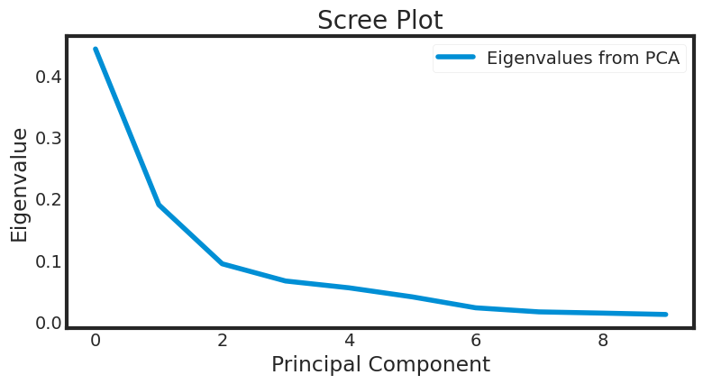

```python
#PCA wirh 10 components
pca_breast2 = PCA(n_components=10)
fit = pca_breast2.fit_transform(X)

#identifying explained variance for each component
variance = pca_breast2.explained_variance_ratio_
plt.plot(variance)
plt.title('Scree Plot')
plt.xlabel('Principal Component')
plt.ylabel('Eigenvalue')

leg = plt.legend(['Eigenvalues from PCA'], loc='best', borderpad=0.3,shadow=False,markerscale=0.4)
leg.get_frame().set_alpha(0.4)
plt.show()
```

A scree plot allows us to understand what the minimal number of principal components needed is to explain an optimal amount of variance in our dataset. This can be seen at the 'elbow' of the scree plot. Once the elbow has been reached, the amount of variance explained by the following principal components decreases steadily and asymptotes to 0. From this scree plot, we can see that the elbow is at 2. Therefore, for our upcoming model, we will be retaining the first three principal component (0,1,2). To learn more about interpreting scree plots with PCA look over [here](https://sanchitamangale12.medium.com/scree-plot-733ed72c8608).

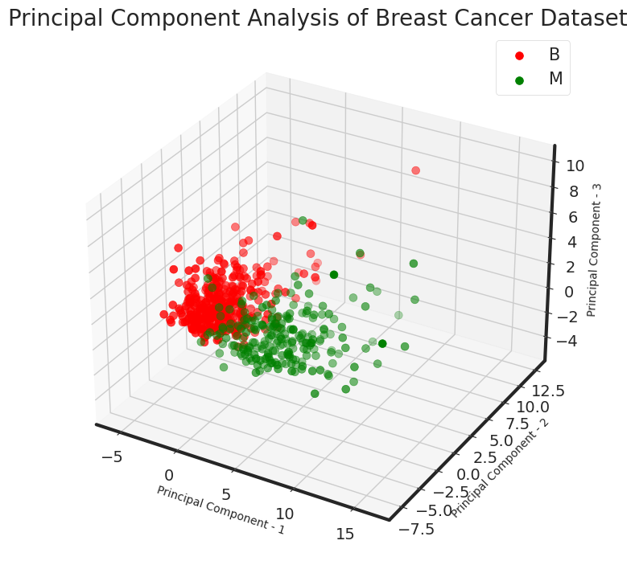

```python
fig = plt.figure(figsize=(8,8))
ax = fig.add_subplot(111, projection='3d')
ax.set_xlabel('Principal Component - 1',fontsize=10)
ax.set_ylabel('Principal Component - 2',fontsize=10)
ax.set_zlabel('Principal Component - 3',fontsize=10)
ax.set_title("Principal Component Analysis of Breast Cancer Dataset",fontsize=20)
targets = ['B', 'M']
colors = ['r', 'g']
for target, color in zip(targets,colors):
    indicesToKeep = diagnostic['diagnosis'] == target
    ax.scatter(principal_breast_Df.loc[indicesToKeep, 'principal component 1'], principal_breast_Df.loc[indicesToKeep, 'principal component 2'], principal_breast_Df.loc[indicesToKeep, 'principal component 3'], c = color, s = 50)

plt.legend(targets,prop={'size': 15})
plt.show()
```

When we plot the three principal components and their relation to our patient diagnoses, we can see that there is a visible distinction between patients who have malignant tumors and patietns who have benign tumors. Again, we can see that majority of the explained variance lies towards PC1, then PC2, and lastly PC3. We will be using this PCA model when building our predictive model.

# **Exploratory Visualizations**

In this section of our analysis, we will be further exploring the features that are in our data sets, and get a beter understanding of the relationships they hold.

We will first start with our **demographic** dataset. To reiterate, we want to see what factors hold a higher correlation to a patients death after being diagnosed with breast cancer. We can first take a look at a statistical summary of all of the values collected in out demographic dataset.

```python
demographic.describe()
```

|  | Age | Grade | Tumor Size | Estrogen Status | Progesterone Status | Regional Node Examined | Reginol Node Positive | Survival Months |
| --- | --- | --- | --- | --- | --- | --- | --- | --- |
| count | 4024.000000 | 4024.000000 | 4024.000000 | 4024.0 | 4024.0 | 4024.000000 | 4024.000000 | 4024.000000 |
| mean | 53.972167 | 2.150596 | 30.473658 | 1.0 | 1.0 | 14.357107 | 4.158052 | 71.297962 |
| std | 8.963134 | 0.638234 | 21.119696 | 0.0 | 0.0 | 8.099675 | 5.109331 | 22.921430 |
| min | 30.000000 | 1.000000 | 1.000000 | 1.0 | 1.0 | 1.000000 | 1.000000 | 1.000000 |
| 25% | 47.000000 | 2.000000 | 16.000000 | 1.0 | 1.0 | 9.000000 | 1.000000 | 56.000000 |
| 50% | 54.000000 | 2.000000 | 25.000000 | 1.0 | 1.0 | 14.000000 | 2.000000 | 73.000000 |
| 75% | 61.000000 | 3.000000 | 38.000000 | 1.0 | 1.0 | 19.000000 | 5.000000 | 90.000000 |
| max | 69.000000 | 4.000000 | 140.000000 | 1.0 | 1.0 | 61.000000 | 46.000000 | 107.000000 |

Now lets take a closer look at the age and race values collected in our dataset and see how they relate to the patients survival. We may first observe a chart of the ages of our patients

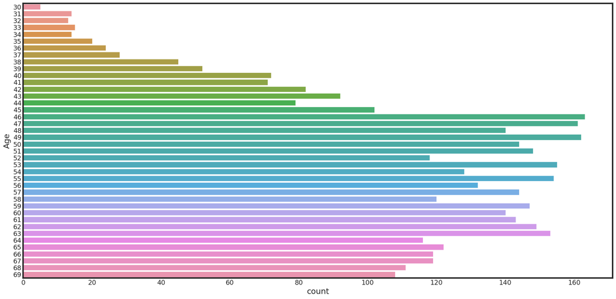

```python
demographic.head()
fig = plt.figure(figsize = (20,10))
sns.countplot(y = 'Age', data = demographic)
```

This summary allows us to understand that our data was collected on females between the ages of 30 and 69, with the avg age being 54.

Now, lets take a look at the race values

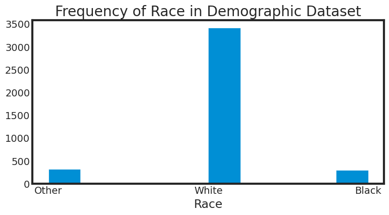

```python
race = demographic['Race ']

# Create a histogram of the column
plt.hist(race)
plt.xlabel('Race')
plt.title('Frequency of Race in Demographic Dataset')
plt.show()
```

Now, we want to see if the age or race of an individual affected the individuals survival and predicted # of survival months. Here, we can calculate the survival based on the race

```python
race_groups = demographic.groupby('Race ')
proportions = race_groups['Status'].value_counts(normalize=True)
print(proportions)
```

```
Race   Status
Black  Alive     0.749141
       Dead      0.250859
Other  Alive     0.896875
       Dead      0.103125
White  Alive     0.850571
       Dead      0.149429
Name: Status, dtype: float64
```

This analysis allows us to see the survival rates of the different race groups. We can see that the patients that were Black died 25% of the time, which is 10% higher than White patients, who died around 15% of the time. This suggests that Black patients are more likely to face death from breast cancer.

Now, we may observe if Age had any impact on the survival months of our patients:

```python
age_bins = [30, 40, 50, 60, 70]
demographic['Age Range'] = pd.cut(demographic['Age'], age_bins)
proportions_age = demographic.groupby(['Age Range', 'Status'])['Status'].count() / demographic.groupby('Age Range')['Status'].count()
print(proportions_age)
```

```
Age Range  Status
(30, 40]   Alive     0.821549
           Dead      0.178451
(40, 50]   Alive     0.870401
           Dead      0.129599
(50, 60]   Alive     0.872294
           Dead      0.127706
(60, 70]   Alive     0.799123
           Dead      0.200877
Name: Status, dtype: float64
```

This output allows us to observe that that the proportion of people who survived was highest in the age range of 50-60, where 12.8% of the people died.The proportion of people who survived was lowest in the age range of 60-70, where 20.1% of the people died. This output suggests that age did have an impact on the survival rate of our patients.

Now, that we have taken a closer look at some demographic values that may predict the survival of a patient, lets observethe **diagnostic** dataset, specifically the smoothness_se value to see if we are able to predict whether a tumor is malignant or benign.

```python
smoothness_bins = [0.001, 0.005, 0.01, 0.015, 0.02, 0.025, 0.03, 0.035]
diagnostic['smoothness_se_range'] = pd.cut(diagnostic['smoothness_se'], smoothness_bins)
proportions_smoothness = diagnostic.groupby(['smoothness_se_range', 'diagnosis'])['diagnosis'].count() / diagnostic.groupby('smoothness_se_range')['diagnosis'].count()
print(proportions_smoothness)
```

```
smoothness_se_range  diagnosis
(0.001, 0.005]       B            0.629921
                     M            0.370079
(0.005, 0.01]        B            0.603217
                     M            0.396783
(0.01, 0.015]        B            0.736842
                     M            0.263158
(0.015, 0.02]        B            1.000000
                     M            0.000000
(0.02, 0.025]        B            0.666667
                     M            0.333333
(0.025, 0.03]        B                 NaN
                     M                 NaN
(0.03, 0.035]        B            0.000000
                     M            1.000000
Name: diagnosis, dtype: float64
```

# **Hypothesis Testing and Model Building**

For this portion of our tutorial, we will now focus on understanding what models best fit our data, and generating a predictive model to determine whether a patient has a malignant or benign tumor.

We wil first start by generating a linear regression model to understand whether or not there is any linear correlation between the diagnosis of a patient's tumor, and factors observed from their screenings.

```python
diagnostic.replace(['M', 'B'], [1, 0], inplace = True)

yvar = diagnostic[['diagnosis']]
xvar = diagnostic.iloc[:,-30:]
xvar = sm.add_constant(xvar)

LinearModel = sm.OLS(yvar, xvar).fit()
print(LinearModel.summary())
```

```
                            OLS Regression Results
==============================================================================
Dep. Variable:              diagnosis   R-squared:                       0.774
Model:                            OLS   Adj. R-squared:                  0.762
Method:                 Least Squares   F-statistic:                     61.53
Date:                Thu, 11 May 2023   Prob (F-statistic):          6.05e-153
Time:                        15:18:36   Log-Likelihood:                 29.650
No. Observations:                 569   AIC:                             2.699
Df Residuals:                     538   BIC:                             137.4
Df Model:                          30
Covariance Type:            nonrobust
===========================================================================================
                              coef    std err          t      P>|t|      [0.025      0.975]
-------------------------------------------------------------------------------------------
const                      -2.0218      0.428     -4.724      0.000      -2.863      -1.181
radius_mean                -0.2178      0.174     -1.255      0.210      -0.559       0.123
texture_mean                0.0045      0.008      0.572      0.567      -0.011       0.020
perimeter_mean              0.0237      0.025      0.946      0.345      -0.026       0.073
area_mean                   0.0003      0.001      0.605      0.545      -0.001       0.001
smoothness_mean             0.0847      2.017      0.042      0.967      -3.878       4.047
compactness_mean           -4.2220      1.334     -3.166      0.002      -6.842      -1.602
concavity_mean              1.3980      1.046      1.337      0.182      -0.656       3.452
concave_points_mean         2.1418      1.979      1.082      0.280      -1.746       6.030
symmetry_mean               0.1027      0.743      0.138      0.890      -1.356       1.562
fractal_dimension_mean      0.0333      5.572      0.006      0.995     -10.913      10.979
radius_se                   0.4350      0.310      1.401      0.162      -0.175       1.045
texture_se                 -0.0068      0.037     -0.183      0.855      -0.079       0.066
perimeter_se               -0.0225      0.041     -0.548      0.584      -0.103       0.058
area_se                    -0.0009      0.001     -0.660      0.509      -0.004       0.002
smoothness_se              15.8543      6.625      2.393      0.017       2.841      28.868
compactness_se              0.0649      2.169      0.030      0.976      -4.197       4.327
concavity_se               -3.5655      1.301     -2.741      0.006      -6.121      -1.010
concave_points_se          10.5680      5.452      1.938      0.053      -0.142      21.278
symmetry_se                 1.6973      2.728      0.622      0.534      -3.661       7.055
fractal_dimension_se       -7.1464     11.676     -0.612      0.541     -30.083      15.791
radius_worst                0.1952      0.058      3.367      0.001       0.081       0.309
texture_worst               0.0072      0.007      1.030      0.303      -0.006       0.021
perimeter_worst            -0.0024      0.006     -0.410      0.682      -0.014       0.009
area_worst                 -0.0010      0.000     -3.163      0.002      -0.002      -0.000
smoothness_worst            0.5429      1.435      0.378      0.705      -2.275       3.361
compactness_worst           0.0672      0.383      0.175      0.861      -0.685       0.820
concavity_worst             0.3812      0.269      1.419      0.156      -0.146       0.909
concave_points_worst        0.4643      0.914      0.508      0.612      -1.332       2.260
symmetry_worst              0.5568      0.494      1.126      0.260      -0.414       1.528
fractal_dimension_worst     4.3035      2.383      1.806      0.072      -0.378       8.985
==============================================================================
Omnibus:                       32.654   Durbin-Watson:                   1.794
Prob(Omnibus):                  0.000   Jarque-Bera (JB):               36.690
Skew:                           0.603   Prob(JB):                     1.08e-08
Kurtosis:                       3.302   Cond. No.                     1.54e+06
==============================================================================

Notes:
[1] Standard Errors assume that the covariance matrix of the errors is correctly specified.
[2] The condition number is large, 1.54e+06. This might indicate that there are
strong multicollinearity or other numerical problems.
```

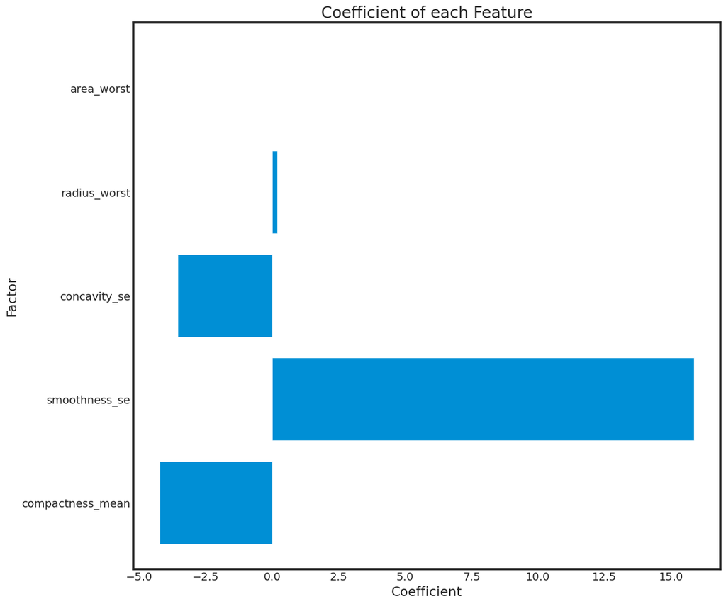

```python
p_values = LinearModel.pvalues
params = LinearModel.params
coeffs = p_values[p_values <= 0.05]
coeffs = coeffs.index.tolist()
sig_coeffs = LinearModel.params[coeffs][1:]
fig, ax = plt.subplots(figsize = (12,12))
ax.barh(sig_coeffs.index.tolist(), width = sig_coeffs)
plt.title('Coefficient of each Feature')
ax.set_ylabel("Factor")
ax.set_xlabel("Coefficient")
```

This plot demonstrates the correlation each statistically significant feature has in determining whether a tumor is malignant or benign. We can see here that smoothness_se (the standard error of the variation in radius lengths along each cell nucleus examined) has the highest correlation. The compactness_mean (the (perimeter^2 / area - 1.0) of each cell nucleus examined) has the next highest correlation. This suggests that when women get their screenings, doctors should pay close attention to the compactness and the radi of each cell nucleus within the tumor examined. Ofcourse this may be hard to do by eye, but an image classifier may be able to compute these values for evaluation.

However, based on this Linear Regression, we can see that it's not a strong model for predicition. The Linear Regression Model has an R-squared value of 0.774, which suggests that only 77.4% of the data is explained through this model. Also recall we previously generated a PCA model to eliminate possiblity of multicollinearity within our model.

In order to procude a more accurate prediction model, let's try using Logistic Regression with our previoulsy generate PCA.

```python
diagnosis = diagnostic[['diagnosis']]
new_df = principal_breast_Df.join(diagnosis, how = 'outer')
new_df.rename(columns={"principal component 1": "PC1", "principal component 2": "PC2", "principal component 3": "PC3"}, inplace = True)

yvar = new_df[['diagnosis']]
xvar = new_df.iloc[:, :3]
xvar = sm.add_constant(xvar)

LogisticModel = sm.Logit(yvar, xvar).fit()

print(LogisticModel.summary())
```

```
Optimization terminated successfully.
         Current function value: 0.108409
         Iterations 10
                           Logit Regression Results
==============================================================================
Dep. Variable:              diagnosis   No. Observations:                  569
Model:                          Logit   Df Residuals:                      565
Method:                           MLE   Df Model:                            3
Date:                Thu, 11 May 2023   Pseudo R-squ.:                  0.8358
Time:                        15:18:37   Log-Likelihood:                -61.685
converged:                       True   LL-Null:                       -375.72
Covariance Type:            nonrobust   LLR p-value:                8.278e-136
==============================================================================
                 coef    std err          z      P>|z|      [0.025      0.975]
------------------------------------------------------------------------------
const         -0.6762      0.242     -2.796      0.005      -1.150      -0.202
PC1            2.3183      0.304      7.616      0.000       1.722       2.915
PC2           -1.2829      0.212     -6.059      0.000      -1.698      -0.868
PC3           -0.4878      0.141     -3.468      0.001      -0.764      -0.212
==============================================================================

Possibly complete quasi-separation: A fraction 0.27 of observations can be
perfectly predicted. This might indicate that there is complete
quasi-separation. In this case some parameters will not be identified.
```

As it can be seen here, the Logistic Regression model has a better R-sqaured value than the Linear Regression Model (rouhgly 84%). It can also be seen that all the principal components here are significant.

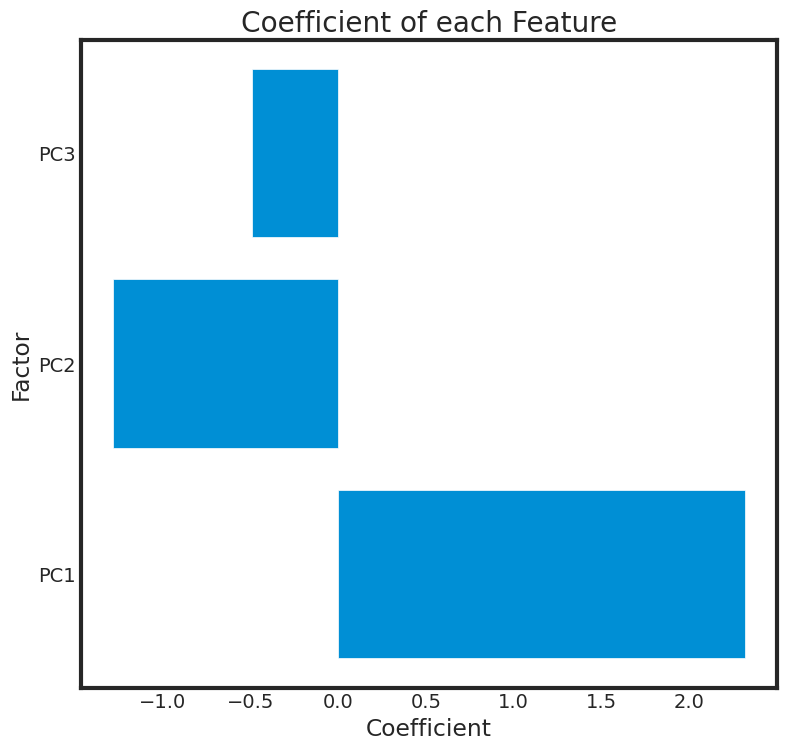

```python
p_values = LogisticModel.pvalues
params = LogisticModel.params
coeffs = p_values[p_values <= 0.05]
coeffs = coeffs.index.tolist()
sig_coeffs = LogisticModel.params[coeffs][1:]
fig, ax = plt.subplots(figsize = (8,8))
ax.barh(sig_coeffs.index.tolist(), width = sig_coeffs)
plt.title('Coefficient of each Feature')
ax.set_ylabel("Factor")
ax.set_xlabel("Coefficient")
```

This aligns with our principal component analysis. We can see that Principal Component 1 explains the highest amount of variance when identifying whether or not the tumor is malignant. To identify which specific features contribute the greatest weight to each principal component, we can go back to look at the linear coefficients of our PCA.

```python
df = pd.DataFrame(data = X, columns = diagnostic.columns[1:])
pca_breast.fit_transform(df)
attr = pd.DataFrame(pca_breast.components_,columns=df.columns,index = ['PC1','PC2', 'PC3'])

nrows, ncols = attr.shape
attr = attr.abs()

fig, axes = plt.subplots(nrows=nrows, ncols=1, figsize=(30, 50*nrows))

for i, (index, row) in enumerate(attr.iterrows()):
    axes[i].barh(row.index, row)
    axes[i].set_title(index)

fig.tight_layout()
plt.show()
```

[figure not shown]

1. Fractal Dimension (Worst)
2. Symmetry (worst)
3. Concave Points (worst)

Here, 'worst' refers to the mean of the three largest values observed for each cell nucleus within each category.

Fractal Dimension for a tumor is related to the structural porosity of the tissue. As carcinogenesis occurs, the fractal dimension of the tissue increases, thus permitting the diagnosis of malignancy.

Symmetry refers to the symmetrical properties of a cell. Morphologically, the cancerous cell is characterized by a large nucleus, having an irregular size and shape. Hence, symmetrial properties (or the lack there of) hold a great impact on identifying whether a cell is malignant or benign.

Lastly, concanve points refers to the number of concave proportions of the contour. This closely related to cancerous cells having asymmetrical structures.

Thus, it makes sense why these three factors hold high importance in identifying malignance.

We will now build our predictive model to guage whether or not a patient has a malignant or benign tumor using logistic regression and our PCA.

```python
X = new_df
y = new_df['diagnosis']

X_train, X_test, y_train, y_test = train_test_split(X, y, test_size=0.3, random_state=40)
LogisticModel = sm.Logit(y_train, X_train).fit()

yhat = LogisticModel.predict(X_test)
prediction = list(map(round, yhat))

cfm = confusion_matrix(y_test, prediction)
true_negative = cfm[0][0]
false_positive = cfm[0][1]
false_negative = cfm[1][0]
true_positive = cfm[1][1]


print('Confusion Matrix: \n', cfm, '\n')

print('True Negative:', true_negative)
print('False Positive:', false_positive)
print('False Negative:', false_negative)
print('True Positive:', true_positive)
print('Correct Predictions = ', accuracy_score(y_test, prediction) * 100, '%')
```

[output not shown]

# Insights and Conclusions

The aim of this project was to understand what factors may affect a certain individual's likelihood for being gravely affected by breast cancer. From our exploratory analysis, we were able to see that majority of the women who were already affected by breast cancer were around 54 years of age. Of those women, the death rates for women between the ages of 60-70 was the highest. This information may urge women who are in their early 30s-40s to get regular screenings for breast cancer in order to avoid late diagnosis. We also discovered that individuals in the Black community seem to be at a higher risk for death, and we may urge them to take earlier precautions. We were also able to conclude from our hypothesis testing that from screening data, certain factors such as the fractal dimension, the symmetry, and the concavity of tumor cells are key traits in identifying whether a tumor is malignant or benign.

We hope that this tutorial gave you a better insight as to what factors may influence patients' mortality in regards to breast cancer. Although a rather brutal topic, we hope that this preliminary analysiz may increase awareness on the importance of breast cancer screening for women, and may even urge women who have higher chances of malignancy to talk to their doctors for prevention techniques.

# Sources and Articles for Further Speculation

[Risk Prediction Models for Breast Cancer](https://academic.oup.com/jbi/article/3/2/144/6144904)

[Tumor Detection with Machine Learning](https://www.sciencedirect.com/topics/computer-science/tumor-detection)

[Principal Component Analysis in Clinial Studies](https://www.ncbi.nlm.nih.gov/pmc/articles/PMC5599285/)

[Machine Learning in Oncology](https://ascopubs.org/doi/full/10.1200/CCI.20.00072)